# Vector Data

D.Hare

May 20, 2018

It is recommended that you go to the gear and change to ‘Chuck Output in Console’ to make the output look cleaner.

This is an introduction to vector data of city location- R doesnt necessary know it is spatial yet.

*A coordinate reference system* A bounding box or extent *Plot order* Data

In the next section we will introduce the *‘sp’* package (spatial points) that will allow us to take fuller advantage of spatial features in R.

data.frame is an object based- data frame will include all the information as well as the data. For instant the corrdinate system as well ‘Sp’ uses a object called s4.

However things are moving towards sf, but still a lot of dependants on sp

Data.fram is an S3 object, while spatial objects are S4 @ are uses in S4- think about ‘dollar sign’ in S3 but a level above (‘dollar sign’ is still column)

```r
library(sp)
cities <- c('Ashland', 'Corvallis', 'Bend', 'Portland', 'Newport')
population <- c(20062, 50297, 61362, 537557, 9603)
longitude <- c(-122.699, -123.275, -121.313, -122.670, -124.054)
latitude <- c(42.189, 44.57, 44.061, 45.523, 44.652)

coords <- data.frame(longitude, latitude)
dat <- data.frame(cities, population)
pts <- SpatialPointsDataFrame(coords, dat)

print(dat)
```

```
##      cities population
## 1   Ashland      20062
## 2 Corvallis      50297
## 3      Bend      61362
## 4  Portland     537557
## 5   Newport       9603
```

```r
print(pts)
```

```
##          coordinates    cities population
## 1 (-122.699, 42.189)   Ashland      20062
## 2  (-123.275, 44.57) Corvallis      50297
## 3 (-121.313, 44.061)      Bend      61362
## 4  (-122.67, 45.523)  Portland     537557
## 5 (-124.054, 44.652)   Newport       9603
```

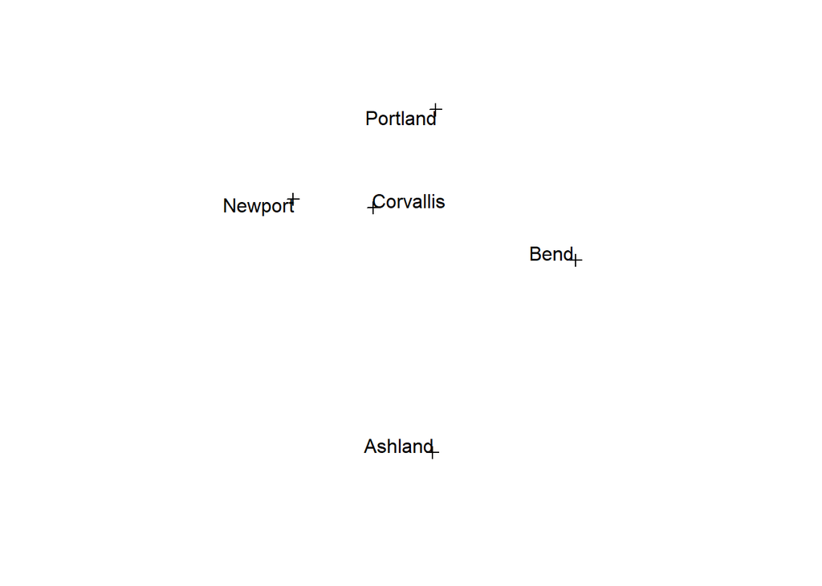

```r
plot(pts) #understands x and y, but not very useful

library(maptools)
plot(pts)
pointLabel(coordinates(pts),labels=pts$cities)
```

```r
summary(pts)
```

```
## Object of class SpatialPointsDataFrame
## Coordinates:
##                min      max
## longitude -124.054 -121.313
## latitude    42.189   45.523
## Is projected: NA
## proj4string : [NA]
## Number of points: 5
## Data attributes:
##        cities    population
##  Ashland  :1   Min.   :  9603
##  Bend     :1   1st Qu.: 20062
##  Corvallis:1   Median : 50297
##  Newport  :1   Mean   :135776
##  Portland :1   3rd Qu.: 61362
##                Max.   :537557
```

```r
str(pts)
```

```
## Formal class 'SpatialPointsDataFrame' [package "sp"] with 5 slots
##   ..@ data       :'data.frame':  5 obs. of  2 variables:
##   .. ..$ cities    : Factor w/ 5 levels "Ashland","Bend",..: 1 3 2 5 4
##   .. ..$ population: num [1:5] 20062 50297 61362 537557 9603
##   ..@ coords.nrs : num(0)
##   ..@ coords     : num [1:5, 1:2] -123 -123 -121 -123 -124 ...
##   .. ..- attr(*, "dimnames")=List of 2
##   .. .. ..$ : NULL
##   .. .. ..$ : chr [1:2] "longitude" "latitude"
##   ..@ bbox       : num [1:2, 1:2] -124.1 42.2 -121.3 45.5
##   .. ..- attr(*, "dimnames")=List of 2
##   .. .. ..$ : chr [1:2] "longitude" "latitude"
##   .. .. ..$ : chr [1:2] "min" "max"
##   ..@ proj4string:Formal class 'CRS' [package "sp"] with 1 slot
##   .. .. ..@ projargs: chr NA
```

```r
pts@coords.nrs
```

```
## numeric(0)
```

```r
pts@data$cities
```

```
## [1] Ashland   Corvallis Bend      Portland  Newport
## Levels: Ashland Bend Corvallis Newport Portland
```

```r
coordinates(pts)
```

```
##      longitude latitude
## [1,]  -122.699   42.189
## [2,]  -123.275   44.570
## [3,]  -121.313   44.061
## [4,]  -122.670   45.523
## [5,]  -124.054   44.652
```

```r
bbox(pts) #bounding box
```

```
##                min      max
## longitude -124.054 -121.313
## latitude    42.189   45.523
```

```r
#vs
pts@bbox
```

```
##                min      max
## longitude -124.054 -121.313
## latitude    42.189   45.523
```

Spatial reference to find your conversion for any reference systems. http://spatialreference.org/ref Google proj4stream

Defining Coordinate System:

```r
pts@proj4string <- CRS('+proj=longlat +ellps=GRS80
                        +datum=NAD83 +no_defs')

summary(pts)
```

```
## Object of class SpatialPointsDataFrame
## Coordinates:
##                min      max
## longitude -124.054 -121.313
## latitude    42.189   45.523
## Is projected: FALSE
## proj4string :
## [+proj=longlat +ellps=GRS80 +datum=NAD83 +no_defs +towgs84=0,0,0]
## Number of points: 5
## Data attributes:
##        cities    population
##  Ashland  :1   Min.   :  9603
##  Bend     :1   1st Qu.: 20062
##  Corvallis:1   Median : 50297
##  Newport  :1   Mean   :135776
##  Portland :1   3rd Qu.: 61362
##                Max.   :537557
```

```r
#Use these CRS packages, still says that "is prjected false" that is because it is in lat, long, not meters
#But you can see that in summary proj4string is full
```

Transforming the Data with sptransform:

```r
pts2 <- spTransform(pts, CRS('+proj=aea +lat_1=29.5 +lat_2=45.5 +lat_0=37.5
                           +lon_0=-96 +x_0=0 +y_0=0 +ellps=GRS80
                           +datum=NAD83 +units=m +no_defs ')) #copied from website specified earlier

proj4string(pts) == proj4string(pts2) #checks to see if the projection is equal
```

```
## [1] FALSE
```

```r
#Returns: FALSE so not equal
summary(pts2)
```

```
## Object of class SpatialPointsDataFrame
## Coordinates:
##                  min      max
## longitude -2188387.0 -1997273
## latitude    830949.2  1187574
## Is projected: TRUE
## proj4string :
## [+proj=aea +lat_1=29.5 +lat_2=45.5 +lat_0=37.5 +lon_0=-96 +x_0=0
## +y_0=0 +ellps=GRS80 +datum=NAD83 +units=m +no_defs +towgs84=0,0,0]
## Number of points: 5
## Data attributes:
##        cities    population
##  Ashland  :1   Min.   :  9603
##  Bend     :1   1st Qu.: 20062
##  Corvallis:1   Median : 50297
##  Newport  :1   Mean   :135776
##  Portland :1   3rd Qu.: 61362
##                Max.   :537557
```

```r
pts3 <- spTransform(pts, proj4string(pts2)) #all this is saying is that we want to transform pts to the projection of pts2

proj4string(pts3) == proj4string(pts2) #these are now the layers I am going to use
```

```
## [1] TRUE
```

Excercise 1 **Finding the nearest cities** Here we are going to start wokring with rgeos that adds a huge amount of functionality

For every single city in out map we want to determine the closest city to each city

```r
library(rgeos)
m <- gDistance(pts2, byid=T) # can be used for comparing a 2nd set as well, but here we are just doing the points within the one dataframe

diag(m) <- NA #diagonal within the matrix (therefore themselves), this removes it

m <- apply(m, 1, which.min) # 1 specifies rows, 2 specifes columns, and looks for the min in each row. For all the rows or all the columns apply a specifc funciton (that is apply), here we are just using the min fucntion
print(m) #shows which pts are closest to each other city
```

```
## 1 2 3 4 5
## 3 5 2 2 2
```

```r
pts2$nearest <- pts2$cities[m] # creates a new column called nearest using names strings
pts2@data #accessing the new data frame
```

```
##      cities population   nearest
## 1   Ashland      20062      Bend
## 2 Corvallis      50297   Newport
## 3      Bend      61362 Corvallis
## 4  Portland     537557 Corvallis
## 5   Newport       9603 Corvallis
```

Excercise 2-Buffers now everything is in meters

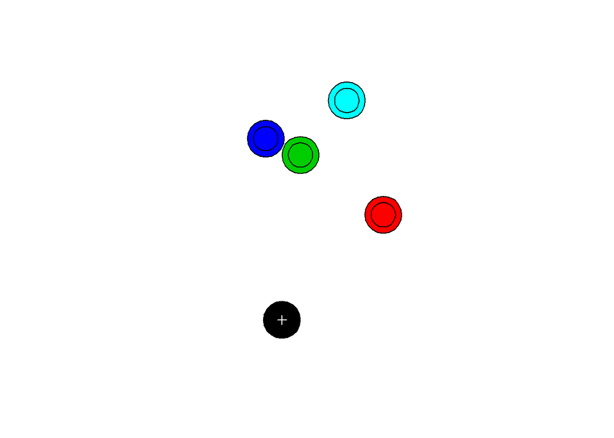

```r
#Adding one buffer
buff <- gBuffer(pts2, byid = T, width = 30000) #new polygon layer called buff which represnts a buffer aaaround each point
plot(buff, col = buff$cities)

#We can also do negative buffers on polygons
plot(gBuffer(buff, width = -10000), add = T)

#Excercise 3
#Select out just one record (Ashland)
ashland <- pts2[pts2$cities == 'Ashland', ] #this has been recommended instead of subset (may be a masking issue but not sure)
plot(ashland, add=T, col="white")
```

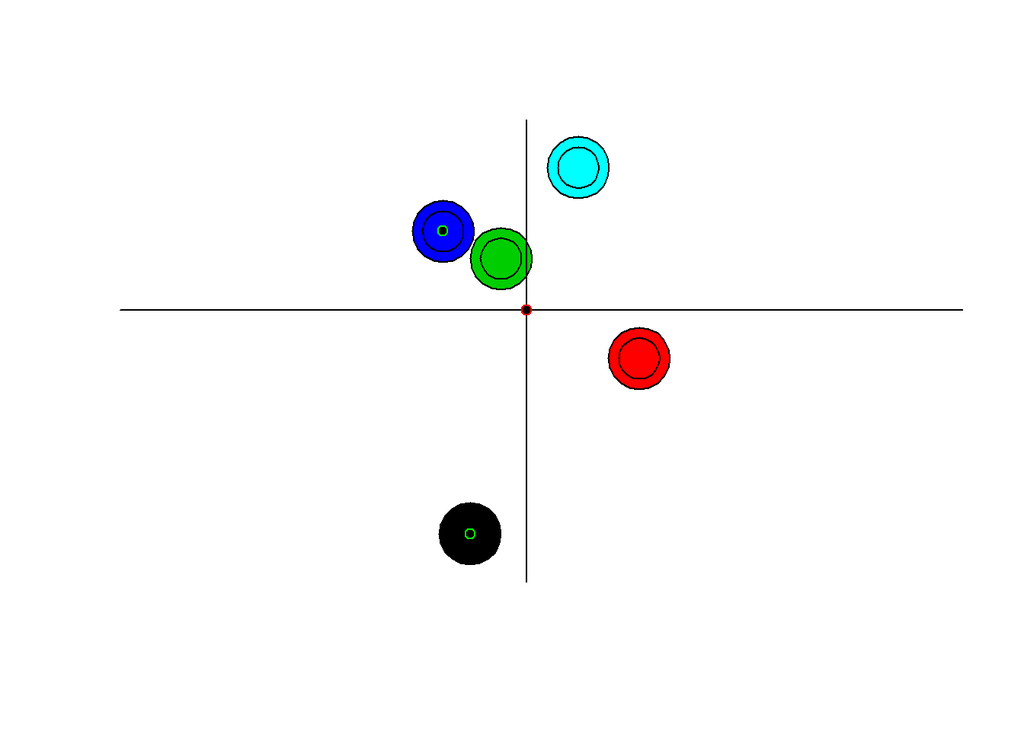

```r
#Select cities with a population < 50,000
towns <- pts2[pts2$population < 50000, ]

#Add these towns to our plot of buffers
plot(buff, col = buff$cities)
plot(gBuffer(buff, width = -10000), add = T)
plot(towns, add = T, col = 'green', pch = 21)

#Plot horizontal and vertical lines at the mean lat/lon
abline(h = mean(coordinates(pts2)[,2]))
abline(v = mean(coordinates(pts2)[,1]))

#Add a point at the centroid of all the cities
plot(gCentroid(pts2), pch = 21, col='red', add = T)
```